# 1. Project Background and Objectives

**Author: XIAO Shengyao, ZHANG Jie**

## 1.1 Project Overview

Allogeneic Hematopoietic Cell Transplantation (HCT) is a critical medical procedure used to treat blood disorders such as leukemia and lymphoma. However, current predictive models often fail to adequately account for factors like socioeconomic status, race, and geographic location, leading to biased predictions that can negatively impact patient outcomes and resource allocation fairness.

The goal of this competition is to develop more accurate and fair predictive models to improve survival rate predictions for allogeneic HCT patients. By integrating diverse data sources and optimizing algorithms, we aim to enhance the model's predictive power while reducing biases across different racial, socioeconomic, and geographic groups. This will help promote equity in healthcare systems.

## 1.2 Evaluation Metric

The competition uses the **Stratified Concordance Index (C-index)** as the evaluation metric. This is a specialized metric for assessing the performance of survival analysis models. Unlike the traditional C-index, the stratified C-index specifically considers predictions across different racial groups to ensure fairness in model performance.

- **C-index**: Measures the model's ability to correctly rank survival times. It ranges from 0 to 1, where:
  - 0.5 indicates random predictions,
  - 1 indicates perfect prediction, and
  - 0 indicates perfect anti-prediction (multiplying predictions by -1 yields 1.0).
- **Stratified C-index**: Adjusts the C-index to account for racial stratification. The final score is the mean minus the standard deviation of the C-index scores calculated within each racial group. This ensures that the model performs accurately and consistently across diverse patient demographics.

### Key Objectives

- **Improve Prediction Accuracy**: Develop models that provide more accurate survival predictions for allogeneic HCT patients.
- **Ensure Fairness**: Reduce biases in predictions across different racial, socioeconomic, and geographic groups.
- **Promote Equity**: Contribute to a more just and effective healthcare system where every patient receives the care they deserve.

# 2. Environment setup

## 2.1 Import library

```python
# from google.colab import drive
# drive.mount('/content/drive')
```

```python
!pip install scikit-learn
!pip install seaborn
!pip install lifelines
!pip install statsmodels
```

|*to run locally, switch to your venv and run 'pip install -r requirements.txt'*

```python
import pandas as pd
import numpy as np
import matplotlib.pyplot as plt
import random
import seaborn as sns
from sklearn.model_selection import train_test_split
from sklearn.preprocessing import StandardScaler, LabelEncoder
from sklearn.impute import SimpleImputer
from sklearn.compose import ColumnTransformer
from scipy.stats import zscore
```

# 3. Data loading and preliminary exploration

## 3.1 Data loading

```python
# train = pd.read_csv('/content/drive/MyDrive/ColabNotebooks/train.csv')
# test = pd.read_csv('/content/drive/MyDrive/ColabNotebooks/test.csv')
# sub = pd.read_csv('/content/drive/MyDrive/ColabNotebooks/sample_submission.csv')


train = pd.read_csv("../data/raw/train.csv")
test = pd.read_csv("../data/raw/test.csv")
sub = pd.read_csv("../data/raw/sample_submission.csv")
```

## 3.2 Data overview

| # | variable | description | type | values |
| --- | --- | --- | --- | --- |
| 0 | dri_score | Refined disease risk index | Categorical | ['Intermediate', 'High', 'N/A - non-malignant ...'] |
| 1 | psych_disturb | Psychiatric disturbance | Categorical | ['Yes', 'No', nan, 'Not done'] |
| 2 | cyto_score | Cytogenetic score | Categorical | ['Intermediate', 'Favorable', 'Poor', 'TBD', ...'] |
| 3 | diabetes | Diabetes | Categorical | ['No', 'Yes', nan, 'Not done'] |
| 4 | hla_match_c_high | Recipient / 1st donor allele level (high resol... | Numerical | NaN |
| 5 | hla_high_res_8 | Recipient / 1st donor allele-level (high resol... | Numerical | NaN |
| 6 | tbi_status | TBI | Categorical | ['No TBI', 'TBI + Cy +- Other', 'TBI +- Other,...'] |
| 7 | arrhythmia | Arrhythmia | Categorical | ['No', nan, 'Yes', 'Not done'] |
| 8 | hla_low_res_6 | Recipient / 1st donor antigen-level (low resol... | Numerical | NaN |
| 9 | graft_type | Graft type | Categorical | ['Peripheral blood', 'Bone marrow'] |
| 10 | vent_hist | History of mechanical ventilation | Categorical | ['No', 'Yes', nan] |
| 11 | renal_issue | Renal, moderate / severe | Categorical | ['No', nan, 'Yes', 'Not done'] |
| 12 | pulm_severe | Pulmonary, severe | Categorical | ['No', 'Yes', nan, 'Not done'] |
| 13 | prim_disease_hct | Primary disease for HCT | Categorical | ['ALL', 'MPN', 'IPA', 'AML', 'MDS', ...] |
| 14 | hla_high_res_6 | Recipient / 1st donor allele-level (high resol... | Numerical | NaN |
| 15 | cmv_status | Donor/recipient CMV serostatus | Categorical | ['+/-', '+/+', '-/-', '-/+', nan] |
| 16 | hla_high_res_10 | Recipient / 1st donor allele-level (high resol... | Numerical | NaN |
| 17 | hla_match_dqb1_high | Recipient / 1st donor allele level (high resol... | Numerical | NaN |
| 18 | tce_imm_match | T-cell epitope immunogenicity/diversity match | Categorical | ['P/P', nan, 'G/G', 'H/H', ...] |
| 19 | hla_nmdp_6 | Recipient / 1st donor matching at HLA-A(lo),-B... | Numerical | NaN |
| 20 | hla_match_c_low | Recipient / 1st donor antigen level (low resol... | Numerical | NaN |
| 21 | rituximab | Rituximab given in conditioning | Categorical | ['No', 'Yes', nan] |
| 22 | hla_match_drb1_low | Recipient / 1st donor antigen level (low resol... | Numerical | NaN |
| 23 | hla_match_dqb1_low | Recipient / 1st donor antigen level (low resol... | Numerical | NaN |
| 24 | prod_type | Product type | Categorical | ['PB', 'BM'] |
| 25 | cyto_score_detail | Cytogenetics for DRI (AML/MDS) | Categorical | ['Intermediate', nan, 'TBD', 'Favorable', ...] |
| 26 | conditioning_intensity | Computed planned conditioning intensity | Categorical | ['RIC', nan, 'NMA', 'MAC', 'TBD', ...] |
| 27 | ethnicity | Ethnicity | Categorical | ['Not Hispanic or Latino', 'Hispanic or Latino', ...] |
| 28 | year_hct | Year of HCT | Numerical | NaN |
| 29 | obesity | Obesity | Categorical | ['No', 'Yes', nan, 'Not done'] |
| 30 | mrd_hct | MRD at time of HCT (AML/ALL) | Categorical | [nan, 'Negative', 'Positive'] |
| 31 | in_vivo_tcd | In-vivo T-cell depletion (ATG/alemtuzumab) | Categorical | ['Yes', 'No', nan] |
| 32 | tce_match | T-cell epitope matching | Categorical | ['Permissive', 'Fully matched', nan, ...] |
| 33 | hla_match_a_high | Recipient / 1st donor allele level (high resol... | Numerical | NaN |
| 34 | hepatic_severe | Hepatic, moderate / severe | Categorical | ['No', nan, 'Yes', 'Not done'] |
| 35 | donor_age | Donor age | Numerical | NaN |
| 36 | prior_tumor | Solid tumor, prior | Categorical | ['Yes', 'No', nan, 'Not done'] |
| 37 | hla_match_b_low | Recipient / 1st donor antigen level (low resol... | Numerical | NaN |
| 38 | peptic_ulcer | Peptic ulcer | Categorical | ['No', nan, 'Yes', 'Not done'] |
| 39 | age_at_hct | Age at HCT | Numerical | NaN |
| 40 | hla_match_a_low | Recipient / 1st donor antigen level (low resol... | Numerical | NaN |
| 41 | gvhd_proph | Planned GVHD prophylaxis | Categorical | ['FK+ MMF +- others', ...] |
| 42 | rheum_issue | Rheumatologic | Categorical | ['No', nan, 'Yes', 'Not done'] |
| 43 | sex_match | Donor/recipient sex match | Categorical | ['M-M', 'F-F', 'F-M', 'M-F', nan] |
| 44 | hla_match_b_high | Recipient / 1st donor allele level (high resol... | Numerical | NaN |
| 45 | race_group | Race | Categorical | ['White', 'Black or African-American', ...] |
| 46 | comorbidity_score | Sorror comorbidity score | Numerical | NaN |
| 47 | karnofsky_score | KPS at HCT | Numerical | NaN |
| 48 | hepatic_mild | Hepatic, mild | Categorical | ['No', 'Yes', nan, 'Not done'] |
| 49 | tce_div_match | T-cell epitope matching | Categorical | ['Permissive mismatched', ...] |
| 50 | donor_related | Related vs. unrelated donor | Categorical | ['Unrelated', 'Related', ...] |
| 51 | melphalan_dose | Melphalan dose (mg/m^2) | Categorical | ['N/A, Mel not given', 'MEL', nan] |
| 52 | hla_low_res_8 | Recipient / 1st donor antigen-level (low resol... | Numerical | NaN |
| 53 | cardiac | Cardiac | Categorical | ['No', 'Yes', nan, 'Not done'] |
| 54 | hla_match_drb1_high | Recipient / 1st donor allele level (high resol... | Numerical | NaN |
| 55 | pulm_moderate | Pulmonary, moderate | Categorical | ['Yes', 'Not done', 'No', nan] |
| 56 | hla_low_res_10 | NaN | Numerical | NaN |
| 57 | efs | Event-free survival | Categorical | ['Event', 'Censoring'] |
| 58 | efs_time | Time to event-free survival, months | Numerical | NaN |

The table provides a description of each variable in the dataset, including their meanings,as well as the type (numerical or categorical) and possible values of the variables. There are 59 variables in total, including both numerical and categorical features.  
In the dataset,

1. Many variables have a significant amount of missing values.
2. Some variables contain ambiguous or unavailable values, such as:
- dri_score and cyto_score include "N/A" or "TBD" instead of usable values.
- Similar issues are found in fields like conditioning_intensity and melphalan_dose.
3. Categorical variables have special values like Not done, which may require standardization or specific handling.
4. Certain categorical variables may have imbalanced distributions, such as efs (event or censoring) and donor_related.  
   Imbalanced data can cause the model to favor majority classes, leading to biased predictions.
5. Potential redundancy exists among variables, such as hla_match_c_high and hla_match_c_low, and other HLA matching-related fields, which may exhibit high correlations.

```python
train.isnull().sum()
```

|  | 0 |
| --- | --- |
| ID | 0 |
| dri_score | 154 |
| psych_disturb | 2062 |
| cyto_score | 8068 |
| diabetes | 2119 |
| hla_match_c_high | 4620 |
| hla_high_res_8 | 5829 |
| tbi_status | 0 |
| arrhythmia | 2202 |
| hla_low_res_6 | 3270 |
| graft_type | 0 |
| vent_hist | 259 |
| renal_issue | 1915 |
| pulm_severe | 2135 |
| prim_disease_hct | 0 |
| hla_high_res_6 | 5284 |
| cmv_status | 634 |
| hla_high_res_10 | 7163 |
| hla_match_dqb1_high | 5199 |
| tce_imm_match | 11133 |
| hla_nmdp_6 | 4197 |
| hla_match_c_low | 2800 |
| rituximab | 2148 |
| hla_match_drb1_low | 2643 |
| hla_match_dqb1_low | 4194 |
| prod_type | 0 |
| cyto_score_detail | 11923 |
| conditioning_intensity | 4789 |
| ethnicity | 587 |
| year_hct | 0 |
| obesity | 1760 |
| mrd_hct | 16597 |
| in_vivo_tcd | 225 |
| tce_match | 18996 |
| hla_match_a_high | 4301 |
| hepatic_severe | 1871 |
| donor_age | 1808 |
| prior_tumor | 1678 |
| hla_match_b_low | 2565 |
| peptic_ulcer | 2419 |
| age_at_hct | 0 |
| hla_match_a_low | 2390 |
| gvhd_proph | 225 |
| rheum_issue | 2183 |
| sex_match | 261 |
| hla_match_b_high | 4088 |
| race_group | 0 |
| comorbidity_score | 477 |
| karnofsky_score | 870 |
| hepatic_mild | 1917 |
| tce_div_match | 11396 |
| donor_related | 158 |
| melphalan_dose | 1405 |
| hla_low_res_8 | 3653 |
| cardiac | 2542 |
| hla_match_drb1_high | 3352 |
| pulm_moderate | 2047 |
| hla_low_res_10 | 5064 |
| efs | 0 |
| efs_time | 0 |

**dtype:** int64

```python
train.describe()
```

|  | ID | hla_match_c_high | hla_high_res_8 | hla_low_res_6 | hla_high_res_6 | hla_high_res_10 | hla_match_dqb1_high | hla_nmdp_6 | hla_match_c_low | hla_match_drb1_low | ... | age_at_hct | hla_match_a_low | hla_match_b_high | comorbidity_score | karnofsky_score | hla_low_res_8 | hla_match_drb1_high | hla_low_res_10 | efs | efs_time |
| --- | --- | --- | --- | --- | --- | --- | --- | --- | --- | --- | --- | --- | --- | --- | --- | --- | --- | --- | --- | --- | --- |
| count | 28800.000000 | 24180.000000 | 22971.000000 | 25530.000000 | 23516.000000 | 21637.000000 | 23601.000000 | 24603.000000 | 26000.000000 | 26157.000000 | ... | 28800.000000 | 26410.000000 | 24712.00000 | 28323.000000 | 27930.00000 | 25147.000000 | 25448.000000 | 23736.000000 | 28800.000000 | 28800.000000 |
| mean | 14399.500000 | 1.764516 | 6.876801 | 5.143322 | 5.109202 | 8.617230 | 1.736876 | 5.160346 | 1.757808 | 1.715296 | ... | 38.663162 | 1.709087 | 1.69962 | 1.702327 | 83.83208 | 6.903448 | 1.707128 | 8.664687 | 0.539306 | 23.237678 |
| std | 8313.988213 | 0.431941 | 1.564313 | 1.207757 | 1.214162 | 1.905125 | 0.447687 | 1.203240 | 0.435453 | 0.451282 | ... | 21.147581 | 0.458259 | 0.46518 | 1.994443 | 11.02884 | 1.565017 | 0.461179 | 1.882746 | 0.498461 | 24.799748 |
| min | 0.000000 | 0.000000 | 2.000000 | 2.000000 | 0.000000 | 3.000000 | 0.000000 | 2.000000 | 0.000000 | 1.000000 | ... | 0.044000 | 0.000000 | 0.00000 | 0.000000 | 40.00000 | 2.000000 | 0.000000 | 4.000000 | 0.000000 | 0.333000 |
| 25% | 7199.750000 | 2.000000 | 6.000000 | 4.000000 | 4.000000 | 7.000000 | 1.000000 | 4.000000 | 2.000000 | 1.000000 | ... | 19.539000 | 1.000000 | 1.00000 | 0.000000 | 70.00000 | 6.000000 | 1.000000 | 7.000000 | 0.000000 | 5.619750 |
| 50% | 14399.500000 | 2.000000 | 8.000000 | 6.000000 | 6.000000 | 10.000000 | 2.000000 | 6.000000 | 2.000000 | 2.000000 | ... | 41.006000 | 2.000000 | 2.00000 | 1.000000 | 90.00000 | 8.000000 | 2.000000 | 10.000000 | 1.000000 | 9.796500 |
| 75% | 21599.250000 | 2.000000 | 8.000000 | 6.000000 | 6.000000 | 10.000000 | 2.000000 | 6.000000 | 2.000000 | 2.000000 | ... | 55.965250 | 2.000000 | 2.00000 | 2.000000 | 90.00000 | 8.000000 | 2.000000 | 10.000000 | 1.000000 | 35.100000 |
| max | 28799.000000 | 2.000000 | 8.000000 | 6.000000 | 6.000000 | 10.000000 | 2.000000 | 6.000000 | 2.000000 | 2.000000 | ... | 73.726000 | 2.000000 | 2.00000 | 10.000000 | 100.00000 | 8.000000 | 2.000000 | 10.000000 | 1.000000 | 156.819000 |

8 rows × 25 columns

```python
train.head()
```

|  | ID | dri_score | psych_disturb | cyto_score | diabetes | hla_match_c_high | hla_high_res_8 | tbi_status | arrhythmia | hla_low_res_6 | ... | tce_div_match | donor_related | melphalan_dose | hla_low_res_8 | cardiac | hla_match_drb1_high | pulm_moderate | hla_low_res_10 | efs | efs_time |
| --- | --- | --- | --- | --- | --- | --- | --- | --- | --- | --- | --- | --- | --- | --- | --- | --- | --- | --- | --- | --- | --- |
| 0 | 0 | N/A - non-malignant indication | No | NaN | No | NaN | NaN | No TBI | No | 6.0 | ... | NaN | Unrelated | N/A, Mel not given | 8.0 | No | 2.0 | No | 10.0 | 0.0 | 42.356 |
| 1 | 1 | Intermediate | No | Intermediate | No | 2.0 | 8.0 | TBI +- Other, >cGy | No | 6.0 | ... | Permissive mismatched | Related | N/A, Mel not given | 8.0 | No | 2.0 | Yes | 10.0 | 1.0 | 4.672 |
| 2 | 2 | N/A - non-malignant indication | No | NaN | No | 2.0 | 8.0 | No TBI | No | 6.0 | ... | Permissive mismatched | Related | N/A, Mel not given | 8.0 | No | 2.0 | No | 10.0 | 0.0 | 19.793 |
| 3 | 3 | High | No | Intermediate | No | 2.0 | 8.0 | No TBI | No | 6.0 | ... | Permissive mismatched | Unrelated | N/A, Mel not given | 8.0 | No | 2.0 | No | 10.0 | 0.0 | 102.349 |
| 4 | 4 | High | No | NaN | No | 2.0 | 8.0 | No TBI | No | 6.0 | ... | Permissive mismatched | Related | MEL | 8.0 | No | 2.0 | No | 10.0 | 0.0 | 16.223 |

5 rows × 60 columns

```python
train.shape
```

```
(28800, 60)
```

```python
train.info()
```

```
<class 'pandas.core.frame.DataFrame'>
RangeIndex: 28800 entries, 0 to 28799
Data columns (total 60 columns):
 #   Column                  Non-Null Count  Dtype
---  ------                  --------------  -----
 0   ID                      28800 non-null  int64
 1   dri_score               28646 non-null  object
 2   psych_disturb           26738 non-null  object
 3   cyto_score              20732 non-null  object
 4   diabetes                26681 non-null  object
 5   hla_match_c_high        24180 non-null  float64
 6   hla_high_res_8          22971 non-null  float64
 7   tbi_status              28800 non-null  object
 8   arrhythmia              26598 non-null  object
 9   hla_low_res_6           25530 non-null  float64
```

[output cut: 52 more lines]

The training data contains missing values in many features.The features efs and efs_time have no missing values, indicating that these are the target variables.We need to handle the missing values appropriately, possibly through imputation or feature engineering.

```python
train['efs'].value_counts()
```

| efs | count |
| --- | --- |
| 1.0 | 15532 |
| 0.0 | 13268 |

**dtype:** int64

# Analyse Exploratoire 1:

```
Plotting for numerical feature: hla_match_c_high
```

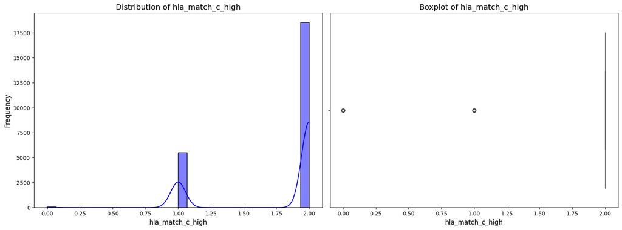

```
Plotting for numerical feature: hla_high_res_8
```

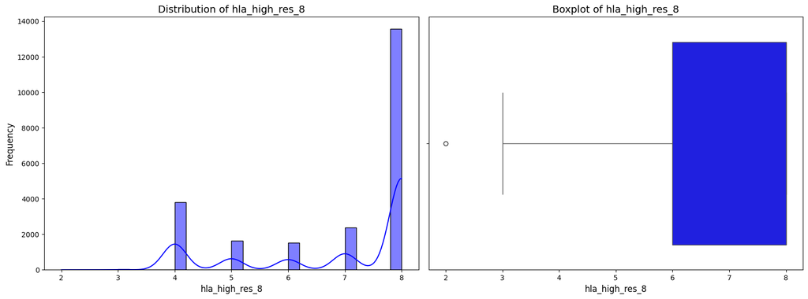

```
Plotting for numerical feature: hla_low_res_6
```

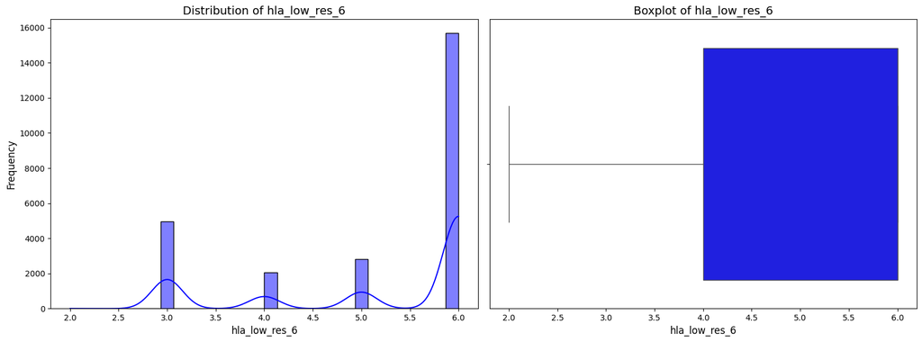

```
Plotting for numerical feature: hla_high_res_6
```

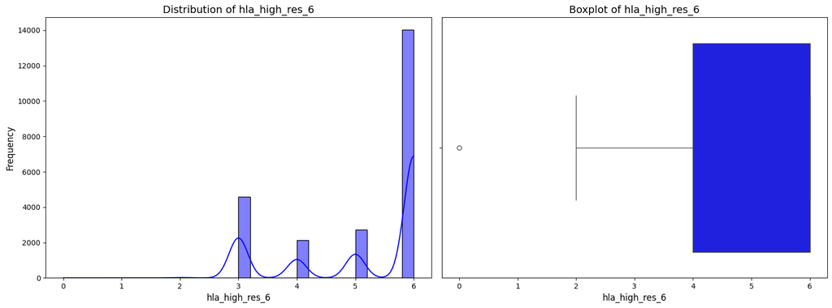

```
Plotting for numerical feature: hla_high_res_10
```

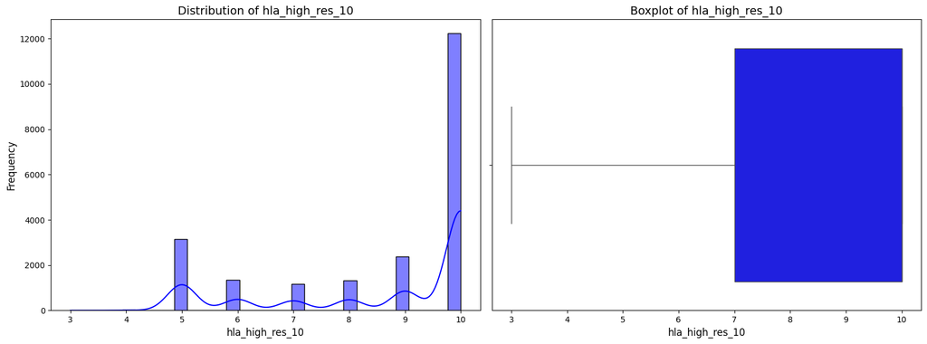

```
Plotting for numerical feature: hla_match_dqb1_high
```

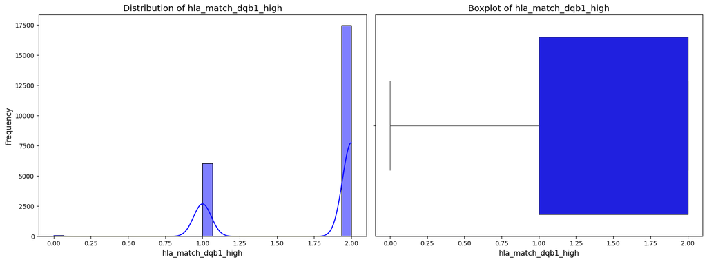

```
Plotting for numerical feature: hla_nmdp_6
```

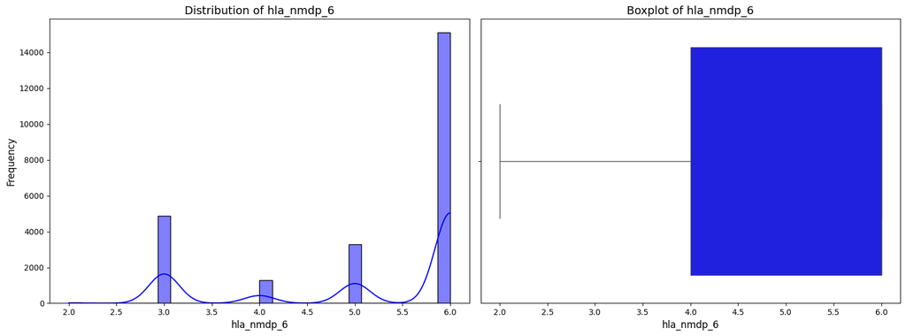

```
Plotting for numerical feature: hla_match_c_low
```

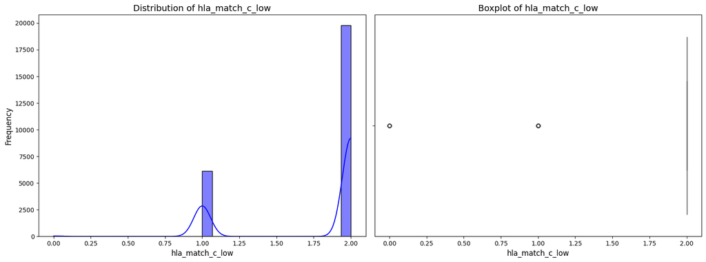

```
Plotting for numerical feature: hla_match_drb1_low
```

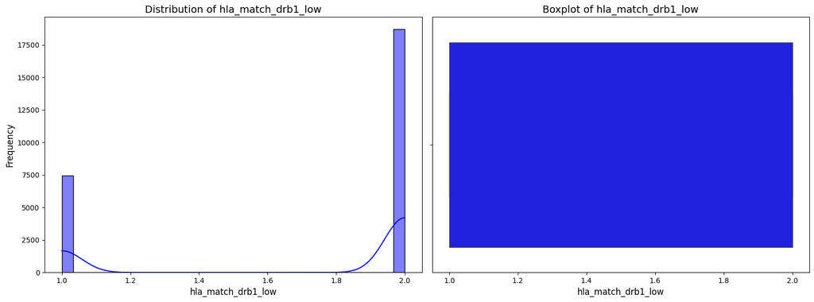

```
Plotting for numerical feature: hla_match_dqb1_low
```

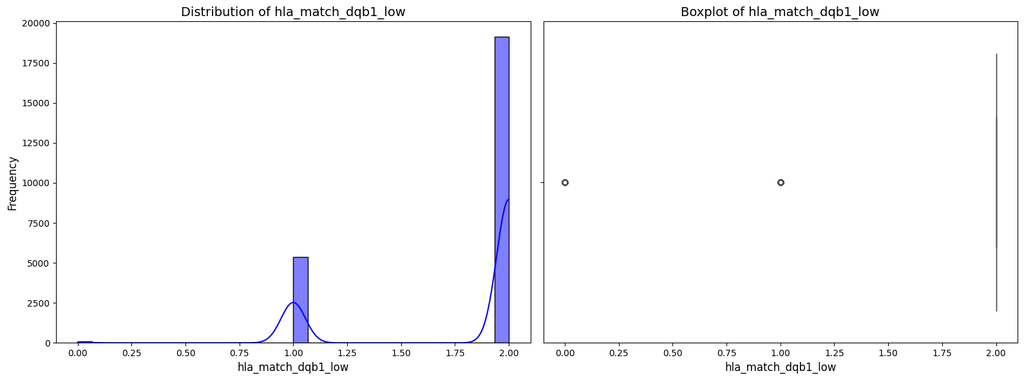

```
Plotting for numerical feature: year_hct
```

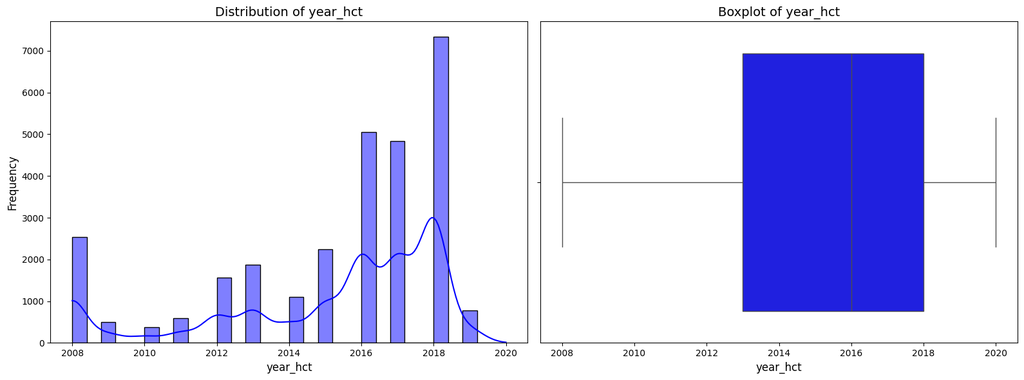

```
Plotting for numerical feature: hla_match_a_high
```

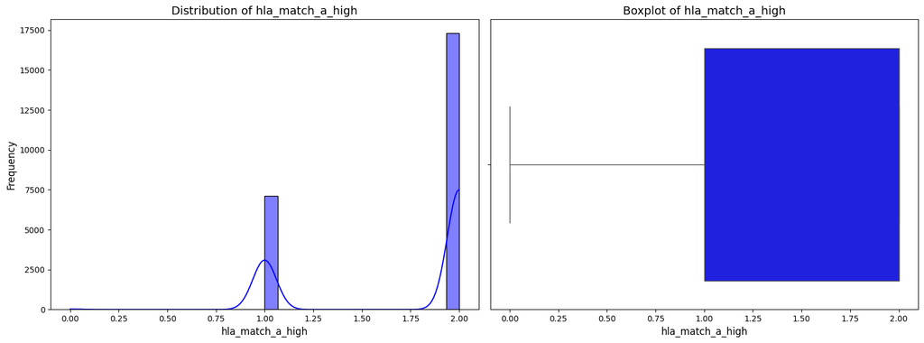

```
Plotting for numerical feature: donor_age
```

[12 more figures not shown]

```python
# Plot the distribution and boxplot of a numerical variable.
def plot_numerical_distribution(data, feature):
    # Create a figure with two subplots (side by side)
    fig, axes = plt.subplots(1, 2, figsize=(16, 6))

    # Plot the distribution
    sns.histplot(data[feature], kde=True, bins=30, ax=axes[0], color='blue')
    axes[0].set_title(f'Distribution of {feature}', fontsize=14)
    axes[0].set_xlabel(feature, fontsize=12)
    axes[0].set_ylabel('Frequency', fontsize=12)

    # Plot the boxplot
    sns.boxplot(x=data[feature], ax=axes[1], color='blue')
    axes[1].set_title(f'Boxplot of {feature}', fontsize=14)
    axes[1].set_xlabel(feature, fontsize=12)

    # Adjust layout to prevent overlap
    plt.tight_layout()
    plt.show()

# Extract numerical features
numerical_features = train.select_dtypes(include=['float64', 'int64']).columns.drop("ID", errors='ignore')

# Iterate through each numerical variable and plot
for feature in numerical_features:
    print(f"Plotting for numerical feature: {feature}")
    plot_numerical_distribution(train, feature)
```

The above picture shows the distribution of all numerical categories. We can see that there is no obvious image that conforms to a specific distribution.

```python
# Plot the distribution of categorical variables, including bar charts and pie charts.
def plot_categorical_distribution(data, col):
    fig, ax = plt.subplots(1, 2, figsize=(15, 8))
    counts = data[col].value_counts()
    colors = [tuple(np.random.choice(256, size=3)/255) for _ in range(len(counts))]

    ax[1].pie(counts.values, labels=counts.index, autopct='%.1f%%', colors=colors, wedgeprops={'edgecolor': 'black'})
    ax[1].set_title('Pie Chart')


    ax[0].barh(range(len(counts)), counts.values, color=colors, edgecolor='black')
    ax[0].set_title('Bar Chart')
    ax[0].set_yticks(range(len(counts)))
    ax[0].set_yticklabels(counts.index)

    plt.tight_layout()
    plt.show()

# Get the category features in the train data
categorical_features = train.select_dtypes(include=['object']).columns

# Traverse each category feature and call the plot_categorical_distribution function
for feature in categorical_features:
    print(f"Plotting for categorical feature: {feature}")
    plot_categorical_distribution(train, feature)
```

```
Output hidden; open in https://colab.research.google.com to view.
```

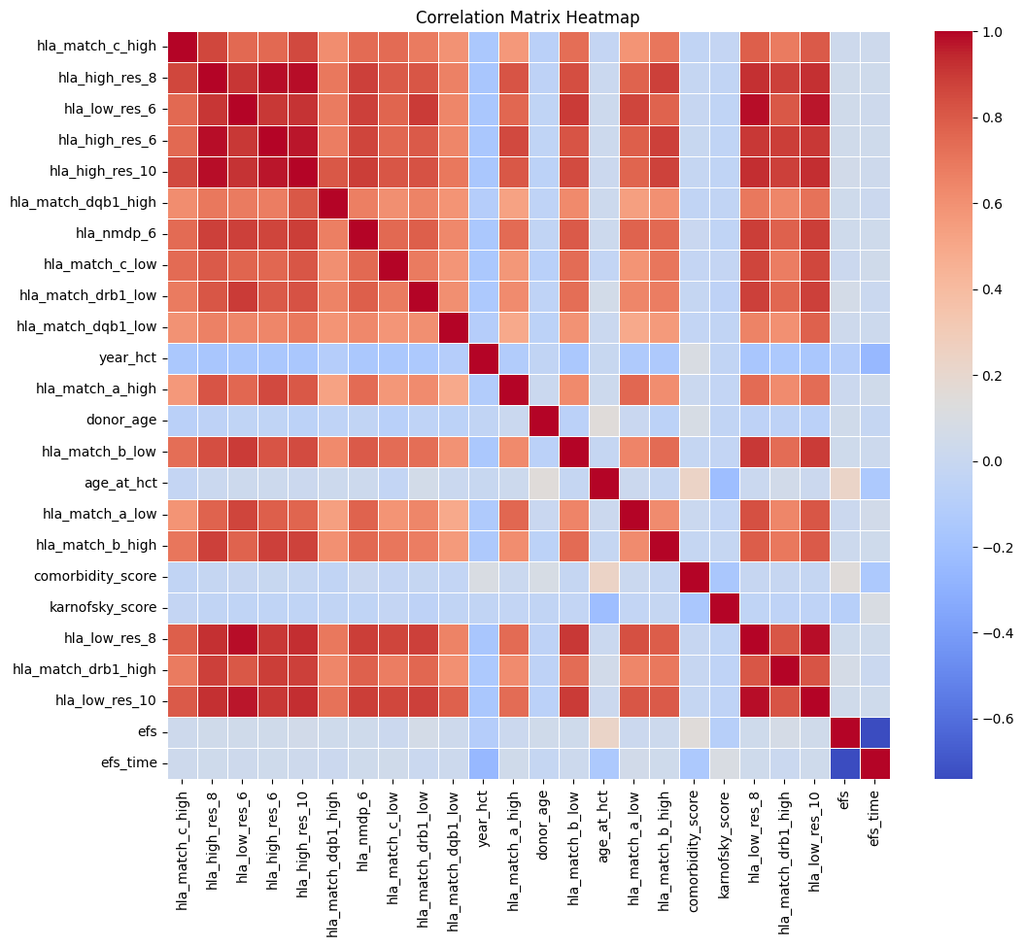

```python
plt.figure(figsize=(12, 10))
correlation_matrix = train[numerical_features].corr()
sns.heatmap(correlation_matrix, annot=False, cmap='coolwarm', fmt='.2f', linewidths=0.5)
plt.title('Correlation Matrix Heatmap')
plt.show()
```

From this correlation matrix, we can see that the efs and efs_time we want to predict are basically unrelated to other numerical categories, so it is difficult to predict them only by numerical columns.

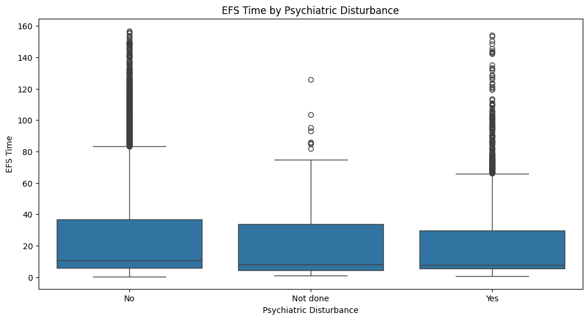

```python
plt.figure(figsize=(12, 6))
sns.boxplot(data=train, x='psych_disturb', y='efs_time')
plt.title('EFS Time by Psychiatric Disturbance')
plt.xlabel('Psychiatric Disturbance')
plt.ylabel('EFS Time')
plt.show()
```

Main Question 1: What factors most influence survival after HCT?

To do this, we will answer the following sub-questions:

```
How does a patient's Disease Risk Index (DRI) affect survival time after HCT?
Does the patient's mental health status (e.g., psychological disorders) have a significant impact on survival after HCT?
Does the degree of HLA matching have a significant impact on survival time?
Is there a correlation between donor-recipient gender matching and survival?
Does the age of the patient significantly affect survival?
How much does the Comorbidity score affect survival after HCT?
Does the type of graft (e.g., peripheral blood or bone marrow) significantly affect survival outcomes?
Does the diabetes and the obesity affect survival outcomes?
```

# 4. Data preparation

This section focuses on preparing the data for further analysis and modeling. It includes several steps:

## 4.1 Mapping Disease Groups

The primary diseases are categorized into broader disease groups for better analysis and modeling.

```python
disease_mapping = {
    'ALL': 'Leukemia',
    'AML': 'Leukemia',
    'MDS': 'Leukemia',
    'Other acute leukemia': 'Leukemia',
    'Other leukemia': 'Leukemia',
    'CML': 'Leukemia',

    'NHL': 'Lymphoma',
    'HD': 'Lymphoma',

    'Solid tumor': 'Solid Tumor',

    'IPA': 'MPN',
    'IEA': 'MPN',

    'SAA': 'Autoimmune and Other Diseases',
    'AI': 'Autoimmune and Other Diseases',
    'HIS': 'Autoimmune and Other Diseases',
    'PCD': 'Autoimmune and Other Diseases',
    'IIS': 'Autoimmune and Other Diseases',
    'IMD': 'Autoimmune and Other Diseases'
}

train['prim_disease_hct'] = train['prim_disease_hct'].map(disease_mapping)
test['prim_disease_hct'] = test['prim_disease_hct'].map(disease_mapping)
```

```python
train['ageXcomorbidity'] = train['age_at_hct'] * train['comorbidity_score']
train['hla_match_score'] = (train['hla_match_a_high'] + train['hla_match_b_high'] + train['hla_match_c_high'])/3

test['ageXcomorbidity'] = test['age_at_hct'] * test['comorbidity_score']
test['hla_match_score'] = (test['hla_match_a_high'] + test['hla_match_b_high'] + test['hla_match_c_high'])/3
```

## 4.2 Outlier Removal

Identify and remove outliers using z-scores to improve model performance.

```python
num_cols = train.select_dtypes(include=['float64', 'int64']).columns
cat_cols = train.select_dtypes(include=['object']).columns

zscores = np.abs(zscore(train[num_cols]))
outliers_zscore = (zscores>3)
train = train[~outliers_zscore.any(axis=1)]
```

```python
train.shape
```

```
(28286, 62)
```

## 4.3 Cleaning

```python
def feature_engineering(data: pd.DataFrame) -> pd.DataFrame:

    bins = [0, 18, 40, 60, 100]
    labels = ['Child', 'Adult', 'Senior', 'Elderly']
    data['age_group'] = pd.cut(data['age_at_hct'], bins=bins, labels=labels)

    return data
```

```python
def clean_melphalan_dose(dose):
    # Check if dose is a number, if yes convert it to string
    if isinstance(dose, (int, float)):
        dose = str(dose)

    if pd.isna(dose):
        return 'Unknown'

    if 'Mel not given' in dose or 'N/A' in dose:
        return 'Not Given'
    elif 'MEL' in dose:
        return 'Given'
    else:
        return 'Unknown'
```

```python
cmv_status_map = {
    '+/+': 'Active CMV Infection',
    '-/+': 'Acute CMV Infection',
    '-/-': 'No CMV Exposure',
    '+/-': 'Past CMV Infection'
}
```

```python
def clean_dri_score(score):
    # Convert score to string if it's a number
    if isinstance(score, (int, float)):
        score = str(score)

    if pd.isna(score):
        return 'Missing'

    if score == 'Low':
        return 'Low'
    elif score == 'Intermediate':
        return 'Intermediate'
    elif score == 'High':
        return 'High'
    elif score == 'Very high':
        return 'Very High'
    elif 'N/A - pediatric' in score:
        return 'Unclassified'
    elif 'TBD cytogenetics' in score:
        return 'Unclassified'
    elif 'Missing disease status' in score:
        return 'Missing'
    elif 'N/A - disease not classifiable' in score:
        return 'Unclassified'
    elif 'TED AML' in score or 'missing cytogenetics' in score:
        return 'Unclassified'
    else:
        return 'Unknown'
```

```python
train = feature_engineering(train)
train['melphalan_dose'] = train['melphalan_dose'].apply(clean_melphalan_dose)
train['cmv_status'] = train['cmv_status'].map(cmv_status_map)
train['dri_score'] = train['dri_score'].apply(clean_dri_score)
```

```python
test = feature_engineering(test)
test['melphalan_dose'] = test['melphalan_dose'].apply(clean_melphalan_dose)
test['cmv_status'] = test['cmv_status'].map(cmv_status_map)
test['dri_score'] = test['dri_score'].apply(clean_dri_score)
```

## 4.4 Handling missing values

Numerical columns are filled with the median, and categorical columns with 'Unknown'.

```python
num_imputer = SimpleImputer(strategy='median')
cat_imputer = SimpleImputer(strategy='constant', fill_value='Unknown')

train[num_cols] = num_imputer.fit_transform(train[num_cols])
train[cat_cols] = cat_imputer.fit_transform(train[cat_cols])
```

```python
num_cols_t = test.select_dtypes(include=['float64', 'int64']).columns
cat_cols_t = test.select_dtypes(include=['object']).columns

num_imputer_t = SimpleImputer(strategy='median')
cat_imputer_t = SimpleImputer(strategy='constant', fill_value='Unknown')

test[num_cols_t] = num_imputer_t.fit_transform(test[num_cols_t])
test[cat_cols_t] = cat_imputer_t.fit_transform(test[cat_cols_t])
```

## 4.5 Categorical feature encoding

Encode the category columns for subsequent model training. Label encoding is used here.

```python
le = LabelEncoder()
for col in cat_cols:
    train[col] = le.fit_transform(train[col])
```

```python
for col in cat_cols_t:
    test[col] = le.fit_transform(test[col])
```

```python
train.head()
```

|  | ID | dri_score | psych_disturb | cyto_score | diabetes | hla_match_c_high | hla_high_res_8 | tbi_status | arrhythmia | hla_low_res_6 | ... | hla_low_res_8 | cardiac | hla_match_drb1_high | pulm_moderate | hla_low_res_10 | efs | efs_time | ageXcomorbidity | hla_match_score | age_group |
| --- | --- | --- | --- | --- | --- | --- | --- | --- | --- | --- | --- | --- | --- | --- | --- | --- | --- | --- | --- | --- | --- |
| 0 | 0.0 | 5 | 0 | 7 | 0 | 2.0 | 8.0 | 0 | 0 | 6.0 | ... | 8.0 | 0 | 2.0 | 0 | 10.0 | 0.0 | 42.356 | 0.000 | 2.000000 | Child |
| 1 | 1.0 | 1 | 0 | 1 | 0 | 2.0 | 8.0 | 6 | 0 | 6.0 | ... | 8.0 | 0 | 2.0 | 3 | 10.0 | 1.0 | 4.672 | 131.115 | 2.000000 | Senior |
| 2 | 2.0 | 5 | 0 | 7 | 0 | 2.0 | 8.0 | 0 | 0 | 6.0 | ... | 8.0 | 0 | 2.0 | 0 | 10.0 | 0.0 | 19.793 | 0.000 | 2.000000 | Adult |
| 4 | 4.0 | 0 | 0 | 7 | 0 | 2.0 | 8.0 | 0 | 0 | 6.0 | ... | 8.0 | 0 | 2.0 | 0 | 10.0 | 0.0 | 16.223 | 29.740 | 2.000000 | Adult |
| 5 | 5.0 | 0 | 0 | 5 | 3 | 2.0 | 7.0 | 1 | 0 | 4.0 | ... | 5.0 | 0 | 2.0 | 3 | 6.0 | 1.0 | 7.095 | 64.286 | 1.666667 | Adult |

5 rows × 63 columns

```python
test
```

|  | ID | dri_score | psych_disturb | cyto_score | diabetes | hla_match_c_high | hla_high_res_8 | tbi_status | arrhythmia | hla_low_res_6 | ... | donor_related | melphalan_dose | hla_low_res_8 | cardiac | hla_match_drb1_high | pulm_moderate | hla_low_res_10 | ageXcomorbidity | hla_match_score | age_group |
| --- | --- | --- | --- | --- | --- | --- | --- | --- | --- | --- | --- | --- | --- | --- | --- | --- | --- | --- | --- | --- | --- |
| 0 | 28800.0 | 1 | 0 | 1 | 0 | 2.0 | 8.0 | 0 | 0 | 6.0 | ... | 1 | 0 | 8.0 | 0 | 2.0 | 0 | 10.0 | 0.000 | 2.0 | Child |
| 1 | 28801.0 | 0 | 0 | 0 | 0 | 2.0 | 8.0 | 1 | 0 | 6.0 | ... | 0 | 0 | 8.0 | 0 | 2.0 | 1 | 10.0 | 131.115 | 2.0 | Senior |
| 2 | 28802.0 | 1 | 0 | 1 | 0 | 2.0 | 8.0 | 0 | 0 | 6.0 | ... | 0 | 0 | 8.0 | 0 | 2.0 | 0 | 10.0 | 0.000 | 2.0 | Adult |

3 rows × 61 columns

## 4.6 Normalizing Numerical Features

```python
num_cols = train.select_dtypes(include=['number']).columns.difference(['ID', 'efs', 'efs_time']) # We do not normalize the ID and the target value to be predicted.

scaler = StandardScaler()
train[num_cols] = scaler.fit_transform(train[num_cols])
train.shape
```

```
(28286, 63)
```

```python
num_cols_t = test.select_dtypes(include=['number']).columns.difference(['ID', 'efs', 'efs_time'])

scaler = StandardScaler()
test[num_cols_t] = scaler.fit_transform(test[num_cols_t])
```

# 5. Analyse exploratoire 2:

```python
train['efs'].value_counts()
```

| efs | count |
| --- | --- |
| 1.0 | 15530 |
| 0.0 | 12756 |

**dtype:** int64

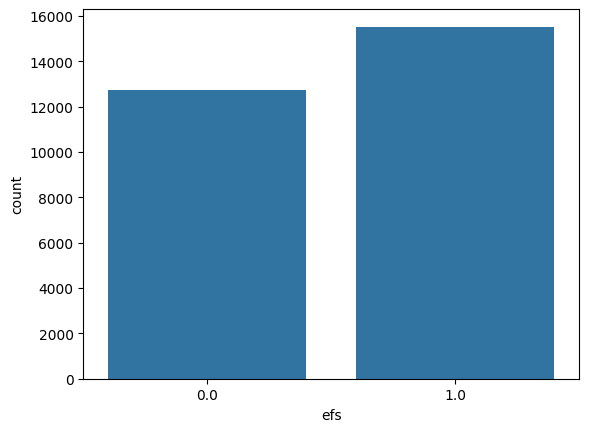

```python
sns.countplot(x='efs', data=train)
plt.show()
```

1. How does the Disease Risk Index (DRI) affect post-HCT survival time?

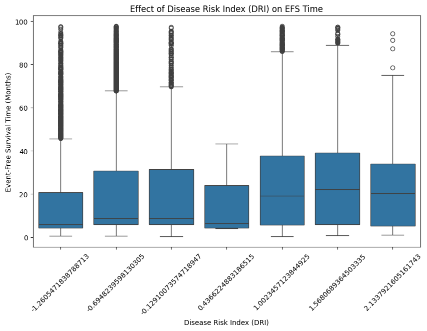

```python
import seaborn as sns
import matplotlib.pyplot as plt

# Analyze the effect of DRI on EFS time
plt.figure(figsize=(10, 6))
sns.boxplot(x='dri_score', y='efs_time', data=train)
plt.title("Effect of Disease Risk Index (DRI) on EFS Time")
plt.xlabel("Disease Risk Index (DRI)")
plt.ylabel("Event-Free Survival Time (Months)")
plt.xticks(rotation=45)
plt.show()
```

```python
from scipy.stats import kruskal

# Perform Kruskal-Wallis test for EFS time across DRI categories
groups = [train['efs_time'][train['dri_score'] == category] for category in train['dri_score'].unique() if category is not None]
stat, p = kruskal(*groups)
print(f"Kruskal-Wallis Test Statistic: {stat}, p-value: {p}")
```

```
Kruskal-Wallis Test Statistic: 1125.499727531583, p-value: 6.338459875095157e-240
```

The p-value is much less than the significance level (usually 0.05), suggesting that there is a significant difference in EFS time between the different DRI groups.  
This suggests that the effect of disease risk index on survival time is statistically significant.

2. Does the patient's psychological health affect post-HCT survival?

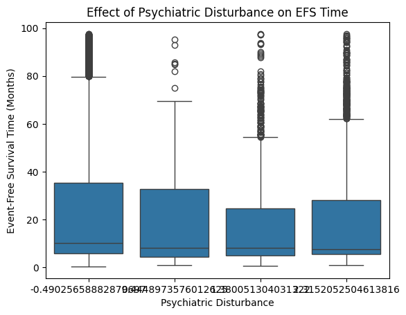

```python
# Analyze the effect of psychiatric disturbance on EFS time
sns.boxplot(x='psych_disturb', y='efs_time', data=train)
plt.title("Effect of Psychiatric Disturbance on EFS Time")
plt.xlabel("Psychiatric Disturbance")
plt.ylabel("Event-Free Survival Time (Months)")
plt.show()
```

The figure illustrates the distribution of post-HCT survival time (EFS time) for patients in different mental health states (Psychiatric Disturbance):

- The range and median of the distribution of EFS time for the different states are relatively close to each other, with no significant pattern or trend.
- The effect of mental health status on EFS time does not appear to be significant.
3. Does HLA matching affect survival time?

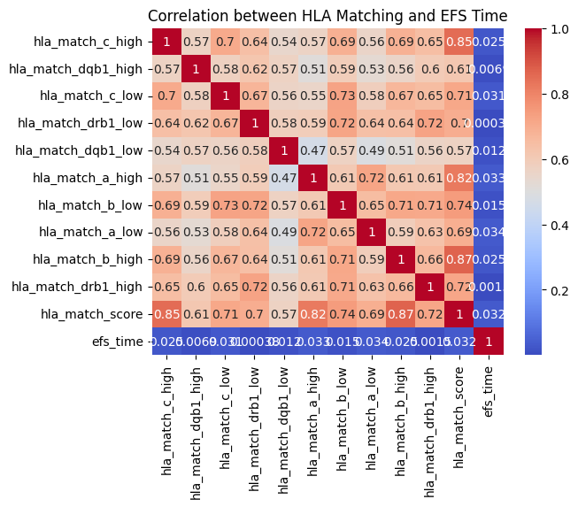

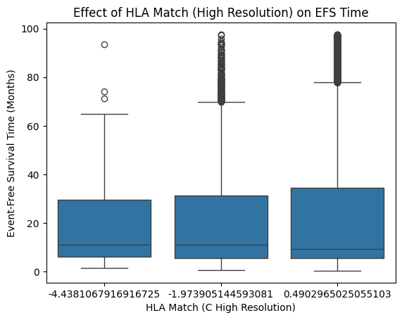

```python
# Correlation analysis for numerical HLA matching features
hla_features = [col for col in train.columns if 'hla_match' in col]
correlation = train[hla_features + ['efs_time']].corr()
sns.heatmap(correlation, annot=True, cmap='coolwarm')
plt.title("Correlation between HLA Matching and EFS Time")
plt.show()

# Boxplot for categorical HLA matches
sns.boxplot(x='hla_match_c_high', y='efs_time', data=train)
plt.title("Effect of HLA Match (High Resolution) on EFS Time")
plt.xlabel("HLA Match (C High Resolution)")
plt.ylabel("Event-Free Survival Time (Months)")
plt.show()
```

Boxplot:

- There was no significant difference in the range and median of the distribution of survival times between the different HLA-matched groups.
- The difference in EFS time between the better and worse HLA-matched groups was not significant.

Based on these analyses, the degree of HLA matching had a small effect and weak correlation on survival time after HCT.

4. Does donor and recipient sex match affect survival outcomes?

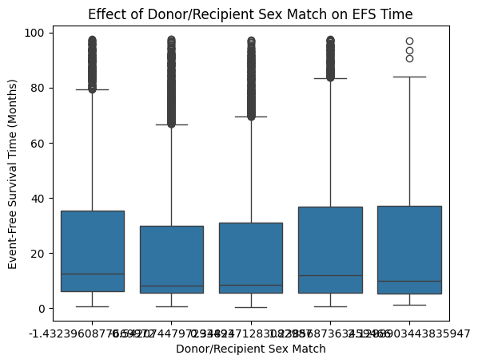

```
Kruskal-Wallis Test Statistic: 182.44968677992046, p-value: 2.220249749130238e-38
```

```python
sns.boxplot(x='sex_match', y='efs_time', data=train)
plt.title("Effect of Donor/Recipient Sex Match on EFS Time")
plt.xlabel("Donor/Recipient Sex Match")
plt.ylabel("Event-Free Survival Time (Months)")
plt.show()

# Statistical Test
sex_groups = [train['efs_time'][train['sex_match'] == group] for group in train['sex_match'].unique() if group is not None]
stat, p = kruskal(*sex_groups)
print(f"Kruskal-Wallis Test Statistic: {stat}, p-value: {p}")
```

The Kruskal-Wallis test has a statistic of 182.45, corresponding to a p-value of 2.22e-38.  
The p-value is much less than the level of significance, indicating that there is a statistically significant difference in survival time between the sex-matched groups.

5. Does the patient's age significantly impact survival outcomes?

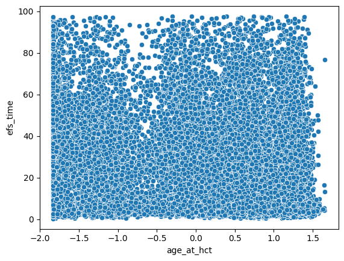

```python
sns.scatterplot(x='age_at_hct', y='efs_time', data=train)
plt.show()
```

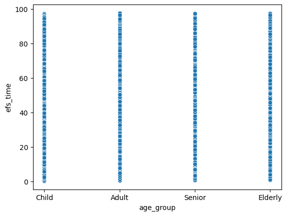

```python
sns.scatterplot(x='age_group', y='efs_time', data=train)
plt.show()
```

```python
# Correlation analysis
correlation_age = train[['age_at_hct', 'efs_time']].corr()
print("Correlation between Age and EFS Time:")
print(correlation_age)
```

```
Correlation between Age and EFS Time:
            age_at_hct  efs_time
age_at_hct    1.000000 -0.159203
efs_time     -0.159203  1.000000
```

Correlation coefficient:

- The Pearson correlation coefficient between patient age (age_at_hct) and survival time (efs_time) is -0.159.
- This is a negative correlation, but the correlation is weak (close to 0).
- This suggests that age has a limited effect on EFS time.

Although the correlation is statistically significant, the actual effect is weak. Age may be a minor factor influencing survival time, but not a major determinant.

6. How does the comorbidity score affect survival time?

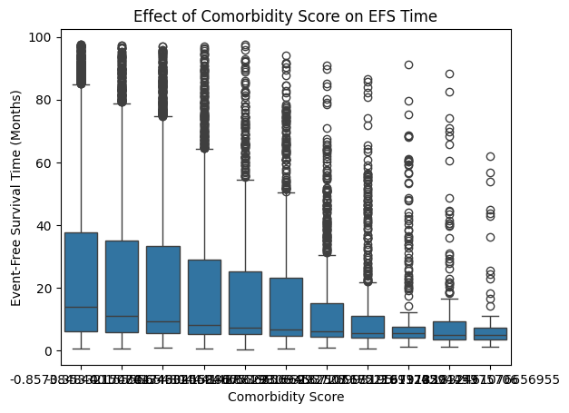

```
Correlation between Comorbidity Score and EFS Time:
                   comorbidity_score  efs_time
comorbidity_score           1.000000 -0.144393
efs_time                   -0.144393  1.000000
```

```python
sns.boxplot(x='comorbidity_score', y='efs_time', data=train)
plt.title("Effect of Comorbidity Score on EFS Time")
plt.xlabel("Comorbidity Score")
plt.ylabel("Event-Free Survival Time (Months)")
plt.show()

# Correlation analysis
correlation_comorbidity = train[['comorbidity_score', 'efs_time']].corr()
print("Correlation between Comorbidity Score and EFS Time:")
print(correlation_comorbidity)
```

BoxPlot:

- The median and range of distribution of EFS times decreased progressively with increasing co-morbidity scores.
- Shorter survival times and a more concentrated distribution in the high co-morbidity score group may indicate that co-morbidity severity is associated with a poorer survival prognosis.
- Although trends were evident, the range of overlap between groups was large, suggesting that co-morbidity score was not the sole determinant.

Correlation Analysis:

- The Pearson correlation coefficient between comorbidity_score and survival time (efs_time) was -0.144.
- This is a weak negative correlation, with an increase in comorbidity_score being associated with a slight decrease in EFS_time, but to a lesser extent.
7. Does graft type significantly affect survival outcomes?

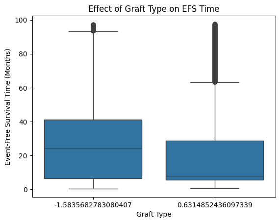

```python
sns.boxplot(x='graft_type', y='efs_time', data=train)
plt.title("Effect of Graft Type on EFS Time")
plt.xlabel("Graft Type")
plt.ylabel("Event-Free Survival Time (Months)")
plt.show()
```

8. How does Obesity and diabetes affect survival outcomes?

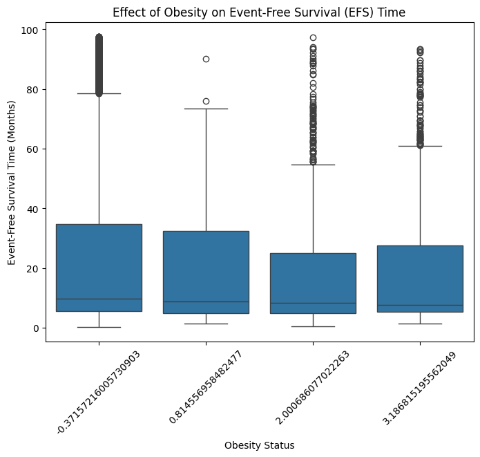

```
Kruskal-Wallis Test for Obesity: Statistic=133.03402877927107, p-value=1.1999900151436835e-28
```

```python
plt.figure(figsize=(8, 6))
sns.boxplot(x='obesity', y='efs_time', data=train)
plt.title("Effect of Obesity on Event-Free Survival (EFS) Time")
plt.xlabel("Obesity Status")
plt.ylabel("Event-Free Survival Time (Months)")
plt.xticks(rotation=45)
plt.show()


# Separate groups by obesity status
obesity_groups = [train[train['obesity'] == category]['efs_time'] for category in train['obesity'].unique()]
stat_obesity, p_obesity = kruskal(*obesity_groups)

print(f"Kruskal-Wallis Test for Obesity: Statistic={stat_obesity}, p-value={p_obesity}")
```

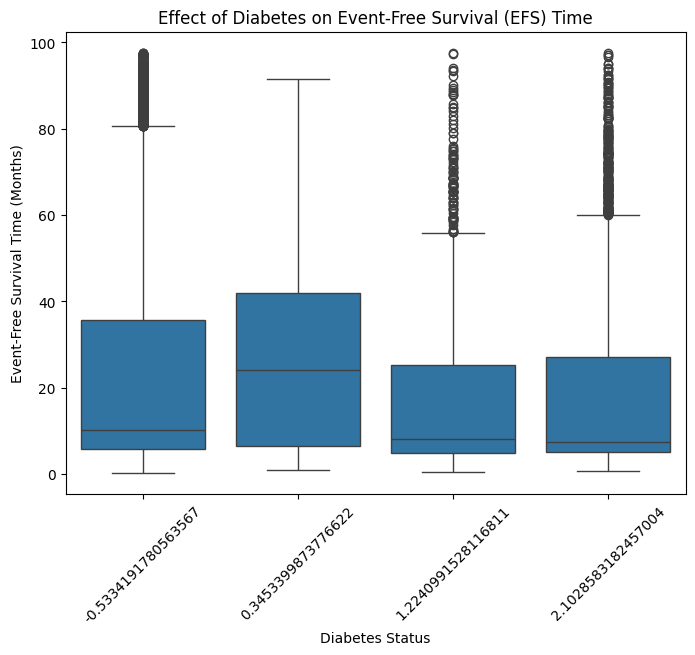

```
Kruskal-Wallis Test for Diabetes: Statistic=294.22774550233254, p-value=1.7660675983052985e-63
```

```python
# Boxplot for diabetes
plt.figure(figsize=(8, 6))
sns.boxplot(x='diabetes', y='efs_time', data=train)
plt.title("Effect of Diabetes on Event-Free Survival (EFS) Time")
plt.xlabel("Diabetes Status")
plt.ylabel("Event-Free Survival Time (Months)")
plt.xticks(rotation=45)
plt.show()

# Separate groups by diabetes status
diabetes_groups = [train[train['diabetes'] == category]['efs_time'] for category in train['diabetes'].unique()]
stat_diabetes, p_diabetes = kruskal(*diabetes_groups)

print(f"Kruskal-Wallis Test for Diabetes: Statistic={stat_diabetes}, p-value={p_diabetes}")
```

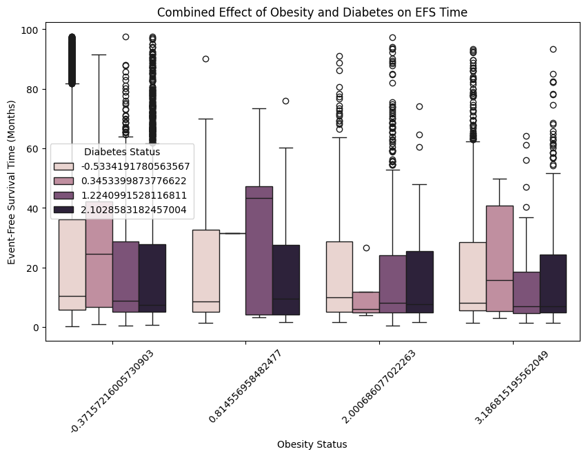

```
                              sum_sq       df          F        PR(>F)
C(obesity)              2.480055e+04      3.0  18.030631  1.099605e-11
C(diabetes)             7.463879e+04      3.0  54.264301  5.761407e-35
C(obesity):C(diabetes)  3.627865e+03      9.0   0.879183  5.429854e-01
Residual                1.296149e+07  28270.0        NaN           NaN
```

```python
# Combined effect
plt.figure(figsize=(10, 6))
sns.boxplot(x='obesity', y='efs_time', hue='diabetes', data=train)
plt.title("Combined Effect of Obesity and Diabetes on EFS Time")
plt.xlabel("Obesity Status")
plt.ylabel("Event-Free Survival Time (Months)")
plt.xticks(rotation=45)
plt.legend(title="Diabetes Status")
plt.show()

# Install statsmodels
%pip install statsmodels

import statsmodels.api as sm
from statsmodels.formula.api import ols

# Two-way ANOVA
model = ols('efs_time ~ C(obesity) + C(diabetes) + C(obesity):C(diabetes)', data=train).fit()
anova_table = sm.stats.anova_lm(model, typ=2)
print(anova_table)
```

```python
# Correlation between diabetes and survival
correlation_diabetes = train[['diabetes', 'efs_time']].groupby('diabetes').mean()
print("Mean EFS Time by Diabetes Status:")
print(correlation_diabetes)

# Correlation between obesity and survival
correlation_obesity = train[['obesity', 'efs_time']].groupby('obesity').mean()
print("Mean EFS Time by Obesity Status:")
print(correlation_obesity)
```

```
Mean EFS Time by Diabetes Status:
            efs_time
diabetes
-0.533419  22.576040
 0.345340  26.704051
 1.224099  17.370461
 2.102858  18.227836
Mean EFS Time by Obesity Status:
            efs_time
obesity
-0.371572  22.097384
 0.814557  21.546125
 2.000686  17.043083
 3.186815  18.365199
```

Mean EFS Times by Category

# 6. Model Building and Testing

## Helper functions for model performance evaluation graphs

```python
from sklearn.metrics import roc_curve, auc

# Plot the Receiver Operating Characteristic (ROC) curve.
def plot_roc_curve(y_true, y_pred, title='ROC Curve'):
    # Calculate the ROC curve
    fpr, tpr, _ = roc_curve(y_true, y_pred)
    roc_auc = auc(fpr, tpr)

    # Plot the ROC curve
    plt.figure(figsize=(8, 6))
    plt.plot(fpr, tpr, color='blue', lw=2, label=f'ROC Curve (AUC = {roc_auc:.2f})')
    plt.plot([0, 1], [0, 1], color='red', linestyle='--', label='Random Guess')
    plt.title(title, fontsize=14)
    plt.xlabel('False Positive Rate', fontsize=12)
    plt.ylabel('True Positive Rate', fontsize=12)
    plt.legend(loc='lower right')
    plt.grid(True, linestyle='--', alpha=0.7)
    plt.show()
```

```python
from sklearn.metrics import precision_recall_curve

# Plot the Precision-Recall (PR) curve.
def plot_pr_curve(y_true, y_pred):
    precision, recall, _ = precision_recall_curve(y_true, y_pred)

    plt.figure(figsize=(8, 6))
    plt.plot(recall, precision, label='Precision-Recall Curve')
    plt.xlabel('Recall')
    plt.ylabel('Precision')
    plt.title('Precision-Recall Curve')
    plt.grid()
    plt.show()
```

```python
from sklearn.metrics import confusion_matrix, ConfusionMatrixDisplay

# Plot the Confusion Matrix curve.
def plot_confusion_matrix(y_true, y_pred, labels=None):
    cm = confusion_matrix(y_true, y_pred, labels=labels)
    disp = ConfusionMatrixDisplay(confusion_matrix=cm, display_labels=labels)
    disp.plot(cmap='Blues')
    plt.title('Confusion Matrix')
    plt.show()
```

## 6.1 Dataset Partitioning

The training set is divided into 80% for training and 20% for validation.

```python
X = train.drop(['efs', 'efs_time'], axis = 1)
y = train[['efs', 'efs_time']]

X_train, X_val, y_train, y_val = train_test_split(X, y, test_size=0.2, random_state=42)
print(X_train.shape)
print(X_val.shape)
```

```
(22628, 61)
(5658, 61)
```

## 6.2 Random Forest

### 6.2.1 Random Forest Regressor for efs_time

```python
from sklearn.ensemble import RandomForestRegressor
from sklearn.metrics import mean_squared_error
from lifelines.utils import concordance_index
from sklearn.preprocessing import LabelEncoder

le = LabelEncoder()
X_train['age_group'] = le.fit_transform(X_train['age_group'])
X_val['age_group'] = le.transform(X_val['age_group'])

rf_model = RandomForestRegressor(n_estimators=100, max_depth=5, random_state=42)
rf_model.fit(X_train, y_train['efs_time'])

y_val_pred = rf_model.predict(X_val)

c_index = concordance_index(y_val['efs_time'], y_val_pred, event_observed=y_val['efs'])
print("C-index on validation set: ", c_index)
```

```
C-index on validation set:  0.5750832833410516
```

```python
!pip install scikit-survival # Install the scikit-survival package, which provides the necessary modules for survival analysis.
```

[output not shown]

```python
import numpy as np
import pandas as pd
from sklearn.preprocessing import LabelEncoder
from sklearn.metrics import mean_squared_error
from lifelines.utils import concordance_index
from sksurv.ensemble import RandomSurvivalForest

le = LabelEncoder()
X_train['age_group'] = le.fit_transform(X_train['age_group'])
X_val['age_group'] = le.transform(X_val['age_group'])

y_train_survival = np.array([(bool(event), time) for event, time in zip(y_train['efs'], y_train['efs_time'])],
                            dtype=[('event', 'bool'), ('time', 'float')])
y_val_survival = np.array([(bool(event), time) for event, time in zip(y_val['efs'], y_val['efs_time'])],
                          dtype=[('event', 'bool'), ('time', 'float')])

# rsf = RandomSurvivalForest(n_estimators=100,
#                            min_samples_split=10,
#                            min_samples_leaf=5,
#                            random_state=42)

# rsf.fit(X_train, y_train_survival)

# y_val_pred_risk = rsf.predict(X_val)

# c_index = concordance_index(y_val['efs_time'], y_val_pred_risk, event_observed=y_val['efs'])

# print("C-index on validation set: ", c_index)
```

We tried to train the RandomSurvivalForest model, but unfortunately, everytime it fails to run with the cpu.

```python
from sksurv.linear_model import CoxPHSurvivalAnalysis
from lifelines.utils import concordance_index

cox_model = CoxPHSurvivalAnalysis()

cox_model.fit(X_train, y_train_survival)

y_val_pred_risk = cox_model.predict(X_val)

c_index = concordance_index(y_val['efs_time'], -y_val_pred_risk, event_observed=y_val['efs'])
print("C-index (Cox Model): {:.3f}".format(c_index))
```

```
C-index (Cox Model): 0.625
```

We searched for another model of Cox Proportional Hazards. The Cox Proportional Hazards Model implemented using CoxPHSurvivalAnalysis() achieved a C-index of 0.625 on the validation set. This indicates a notable improvement in the model's ability to rank survival times compared to the Random Forest Regressor's C-index of 0.575.

### 6.2.2 Random Forest Classifier for efs

```python
from sklearn.ensemble import RandomForestClassifier
from sklearn.metrics import accuracy_score, roc_auc_score, confusion_matrix, classification_report

# Initialize Random Forest Classifier
rf_classifier = RandomForestClassifier(n_estimators=100, random_state=42)

# Train the model
rf_classifier.fit(X_train, y_train['efs'])

# Predict on the validation set
y_val_pred = rf_classifier.predict(X_val)
y_val_pred_proba = rf_classifier.predict_proba(X_val)[:, 1]  # Get predicted probabilities for the positive class
```

```python
# Evaluate the model
accuracy = accuracy_score(y_val['efs'], y_val_pred)  # Calculate accuracy
roc_auc = roc_auc_score(y_val['efs'], y_val_pred_proba)  # Calculate ROC-AUC score
conf_matrix = confusion_matrix(y_val['efs'], y_val_pred)  # Generate confusion matrix
class_report = classification_report(y_val['efs'], y_val_pred)  # Generate classification report

print("Accuracy on validation set: {:.3f}".format(accuracy))
print("ROC-AUC on validation set: {:.3f}".format(roc_auc))
print("Confusion Matrix:\n", conf_matrix)
print("Classification Report:\n", class_report)
```

```
Accuracy on validation set: 0.666
ROC-AUC on validation set: 0.717
Confusion Matrix:
 [[1321 1230]
 [ 661 2446]]
Classification Report:
               precision    recall  f1-score   support

         0.0       0.67      0.52      0.58      2551
         1.0       0.67      0.79      0.72      3107

    accuracy                           0.67      5658
   macro avg       0.67      0.65      0.65      5658
weighted avg       0.67      0.67      0.66      5658
```

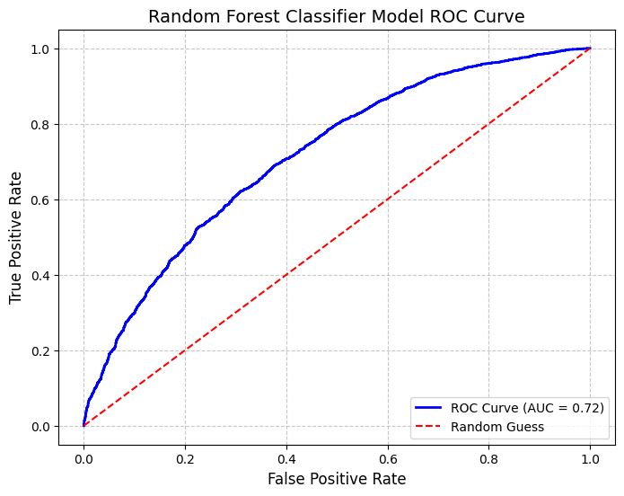

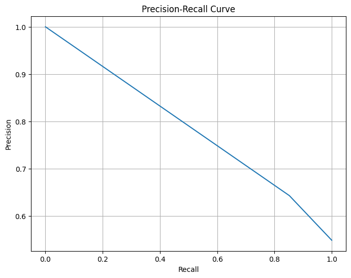

[figure not shown]

```python
plot_roc_curve(y_val['efs'], y_val_pred_proba, title='Random Forest Classifier Model ROC Curve')

plot_pr_curve(y_val['efs'], y_val_pred)

# Convert predicted probabilities to binary labels
threshold = 0.5
y_val_pred_binary = (y_val_pred >= threshold).astype(int)
plot_confusion_matrix(y_val['efs'], y_val_pred_binary, labels=[0, 1])
```